# Project 2B: Disney+ Data

James Kolesar

Tuesday, December 07, 2021 @ 01:04 PM

## Setup

### Packages Used

```r
#It should be noted that in order to run the scripts I needed some packages so I figured I should just load them all here
library(readxl)
library(openxlsx)
library(dplyr)
library(ggplot2)
library(waffle)
```

### Datasets Used

```r
load('../dataprocessed/streamingcontent.Rdata')
```

### Collaborators

None :)

## Visualizations

### Background of the Data

The datasets were downloaded from [Kaggle](https://www.kaggle.com/). You can find the links to their descriptions in the `docsreference` folder.

### Create Analysis Datasets

Complete and run the two scripts found in the `docscripts` folder. Your processed datasets all should be written into the `dataprocessed` folder. Load the resulting `.Rdata` file above under the **Setup** header and use `glimpse()` to explore the structure of each dataset.

#### Dataset #1

The `dplus` dataset contains a variable that gives information about the `rating` for each program offering. Convert the variable into a factor that puts the ratings in (roughly) ascending order of age restriction/audience: `TV-Y`, `TV-Y7`, `TV-Y7-FV`, `TV-G`, `G`, `TV-PG`, `PG`, `PG-13`, `TV-14`. If the `date_added` variable is not already in date format, convert it.

```r
new_dplus = dplus %>%
  mutate(rating = ifelse(rating == "TV-Y", "1.TV-7", rating),
         rating = ifelse(rating == "TV-Y7", "2.TV-Y7", rating),
         rating = ifelse(rating == "TV-Y7-FV", "3.TV-Y7-FV", rating),
         rating = ifelse(rating == "TV-G", "4.TV-G", rating),
         rating = ifelse(rating == "G", "5.G", rating),
         rating = ifelse(rating == "TV-PG", "6.TV-PG", rating),
         rating = ifelse(rating == "PG", "7.PG", rating),
         rating = ifelse(rating == "PG-13", "8.PG-13", rating),
         rating = ifelse(rating == "TV-14", "9.TV-14", rating),
         rating = as.factor(rating),
         date_added = as.Date(date_added))
```

#### Dataset #2

In the `strmtv` dataset, create a new variable that tells you the total number of streaming services that offer each included program.

```r
new_strmtv = strmtv %>%
  mutate(TotalServices = Netflix + Hulu + `Prime Video` + `Disney+`)
```

### Part 1: Violin Plot

Create a violin plot of `release_year` (x-axis) grouped by `type` of program (y-axis) for programs on Disney+. Fill with a color of your choice. Add a boxplot inside the violin plot, as you did in one of the DataCamp exercises. Re-scale the x-axis so that tick marks appear at whole-decade intervals (e.g., 1980, 1990, 2000). Add an appropriate title and axis labels. Use other formatting as you choose to enhance effectiveness/appearance.

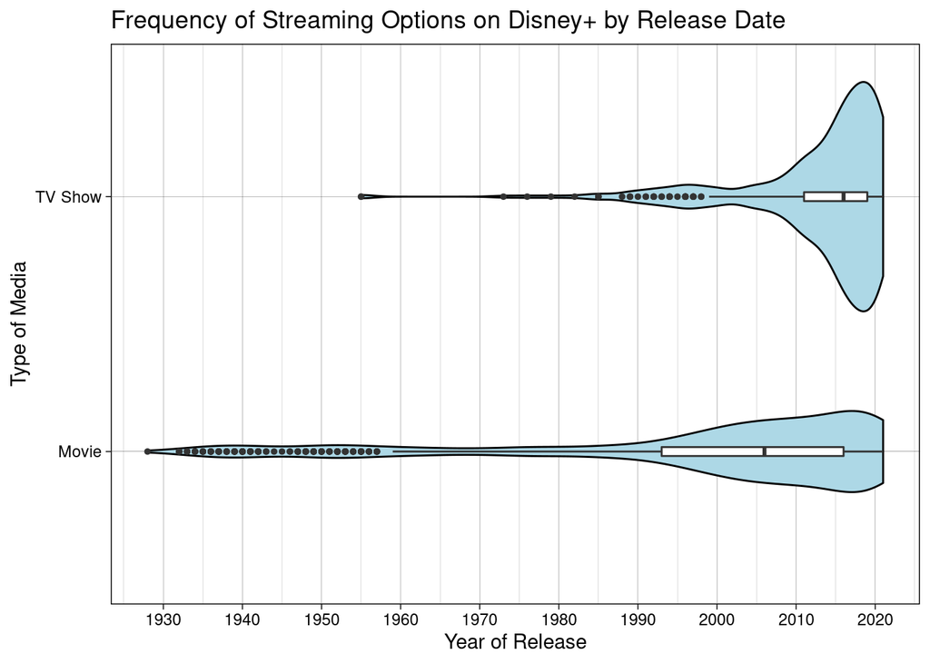

```r
ggplot(data = new_dplus, aes(x = release_year, y = type)) +
  geom_violin(color = 'black', fill = "light blue") +
  geom_boxplot(width = 0.035, outlier.size = 1) +
  theme_linedraw() +
  scale_x_continuous(breaks = seq(1920, 2030, by = 10)) +
  labs(x = "Year of Release", y = "Type of Media", title = "Frequency of Streaming Options on Disney+ by Release Date")
```

### Part 2: Waffle Plot

[figure not shown]

Create a waffle plot to show the distribution of program `type` on Disney+.

- Give the plot the title “Streaming Content on Disney+”.
- Change the colors of the squares to something other than the defaults.
- Use an x-axis label to indicate roughly how many programs each square represents.

Hint: You can use `count()` to find out how many of each `type` of program there is, then use `prop.table(n)` in a mutate statement (along with some other math) to get percentages. Other methods are also possible.

```r
table(new_dplus$type)
```

```
  Movie TV Show
    991     377
```

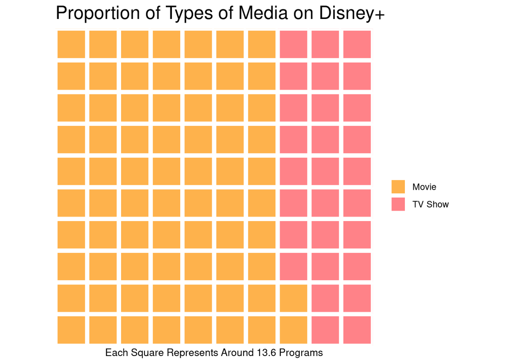

```r
x = c(Movie = 72, `TV Show` = 28) #It should be noted that that waffle plot was throwing in random purple squares when I input the precise percentages, so I rounded to the nearest whole percent

waffle(x, title = "Proportion of Types of Media on Disney+", color = c("#FEB24C", "#FF8288"), xlab = "Each Square Represents Around 13.6 Programs")
```

### Part 3: Bar Plot

Create a horizontal barplot to show the frequencies of the various `rating` categories for programs on Disney+ (i.e., use `y =` rather than `x =` for the variable you are plotting). You will need to remove a couple `NA` values first. Use faceting by `type` so that you have side-by-side plots for the different program types. Add an appropriate title and axis labels, as well as other formatting of your choice to enhance effectiveness/appearance.

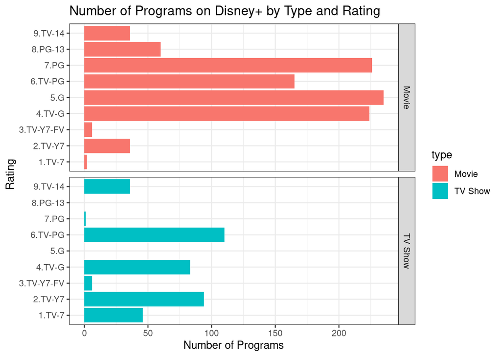

```r
new_new_dplus = new_dplus[complete.cases(new_dplus$rating),] #Making a new data frame only including rows where the rating variable wasn't NA

ggplot(data = new_new_dplus, aes(y = rating, fill = type)) +
  geom_bar(position = 'stack') +
  facet_grid(rows = type~.) +
  theme_bw() +
  labs(title = "Number of Programs on Disney+ by Type and Rating", y = "Rating", x = "Number of Programs")
```

### Part 4: Another Plot

Use one of the sets that contains data about the TV shows available on various streaming services to compare the quantity of Disney’s TV show offerings to the quantity of offerings on other streaming services. Use a plot of your choice to enhance the effectiveness/appearance of the plot.

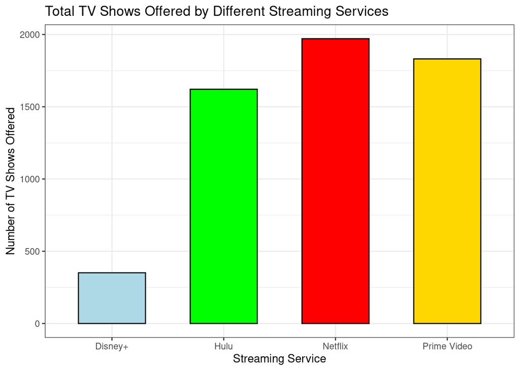

```r
totalTV = new_strmtv %>%
  summarize(Netflix = sum(Netflix), Hulu = sum(Hulu), PV = sum(`Prime Video`), Disney = sum(`Disney+`))

#head(totalTV)

service = c(rep("Netflix", 1971), rep("Hulu", 1621), rep("Prime Video", 1831), rep("Disney+", 351))
totalTVdf = data.frame(service)

ggplot(data = totalTVdf, aes(x = service)) +
  geom_bar(width = .6, color = c('black',"black","black","black"), fill = c('light blue', "green", "red", "gold")) +
  theme_bw() +
  labs(x = "Streaming Service", y = "Number of TV Shows Offered", title = "Total TV Shows Offered by Different Streaming Services")
```

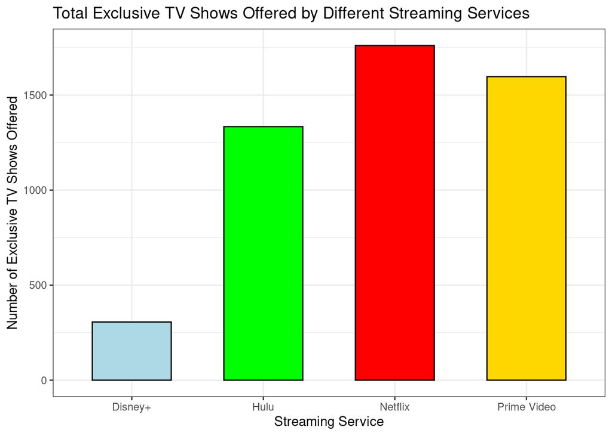

```r
totalExclusives = new_strmtv %>%
  filter(TotalServices == 1) %>%
  summarize(Netflix = sum(Netflix), Hulu = sum(Hulu), PV = sum(`Prime Video`), Disney = sum(`Disney+`))

#head(totalExclusives)

serviceExclusive = c(rep("Netflix", 1761), rep("Hulu", 1334), rep("Prime Video", 1597), rep("Disney+", 306))
totalExclusiveDF = data.frame(serviceExclusive)

ggplot(data = totalExclusiveDF, aes(x = serviceExclusive)) +
  geom_bar(width = .6, color = c('black',"black","black","black"), fill = c('light blue', "green", "red", "gold")) +
  theme_bw() +
  labs(x = "Streaming Service", y = "Number of Exclusive TV Shows Offered", title = "Total Exclusive TV Shows Offered by Different Streaming Services")
```

## Questions

**Question 1:** Based on your plots, make five informational statements or comparisons regarding the Disney+ streaming service.

**ANSWER**

1. The majority of programs offered on Disney+ are movies, as opposed to TV shows.
2. Programs rated for very young audiences on Disney+ tend to be TV shows.
3. Disney+ offers much fewer TV shows when compared to other streaming services, exclusives or otherwise.
4. Most TV shows on Disney+ have been released in the past ten years, and while the same is true for movies it is less so, and the movies released on Disney+ tend to have been released much earlier than TV shows.
5. Programs offered on Disney+ tend to be rated for a younger audience, although not to an extreme degree.

**Question 2:** What other data would you like to have, or which existing variables would you like to see transformed, if you were going to do further explorations or visualizations? Give at least two examples.

**ANSWER**

Definitely information regarding critical/viewer ratings of shows, or statistics on which shows get watched the most. It would be really interesting to see if the discrepancy between Disney+ and other streaming services in terms of quantity of TV shows just comes down to Hulu, Netflix, and Prime Video having a ton of chaff, or if Disney+ is still proportionally very low when it comes to number of *banger* TV shows. I would also like to see data on whether the shows are originals produced by the streaming service themselves. That in conjunction with the aforementioned *banger* statistic could offer some really interesting analysis on whether or not producing your own shows is a good idea for streaming services or if they’re better off licensing.